# Bootstrap

## 2.3 - Russet data

Final comparison with the Russet Data. “ci.spls” is 3 times faster than “ci.rgcca”.

```
## 10 % completed...
## 20 % completed...
## 30 % completed...
## 40 % completed...
## 50 % completed...
## 60 % completed...
## 70 % completed...
## 80 % completed...
## 90 % completed...
## 100 % completed...
```

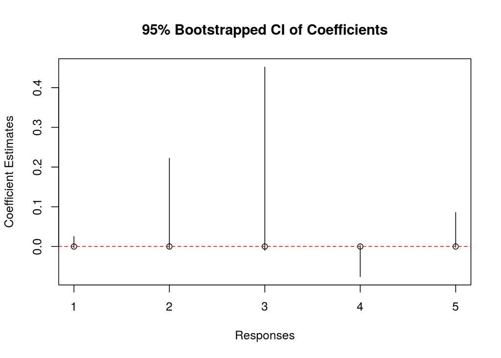

```r
data("Russett")
X_agric         = as.matrix(Russett[,c("gini","farm","rent")])
X_ind           = as.matrix(Russett[,c("gnpr","labo")])
X_polit         = as.matrix(Russett[ ,c("inst", "ecks",  "death","demostab", "dictatur")])

# SPLS
X    = cbind(X_agric, X_ind)
Y    = X_polit
K    = 1
eta  = 0.6
f    = spls(X, Y, K = K, eta = eta)
f$A  = 1:ncol(X)
# CI with SPLS
plot.it  = TRUE
plot.fix = "x"
plot.var = 3
ci.f     = ci.spls(f, plot.it = plot.it, plot.fix = plot.fix, plot.var = plot.var)
```

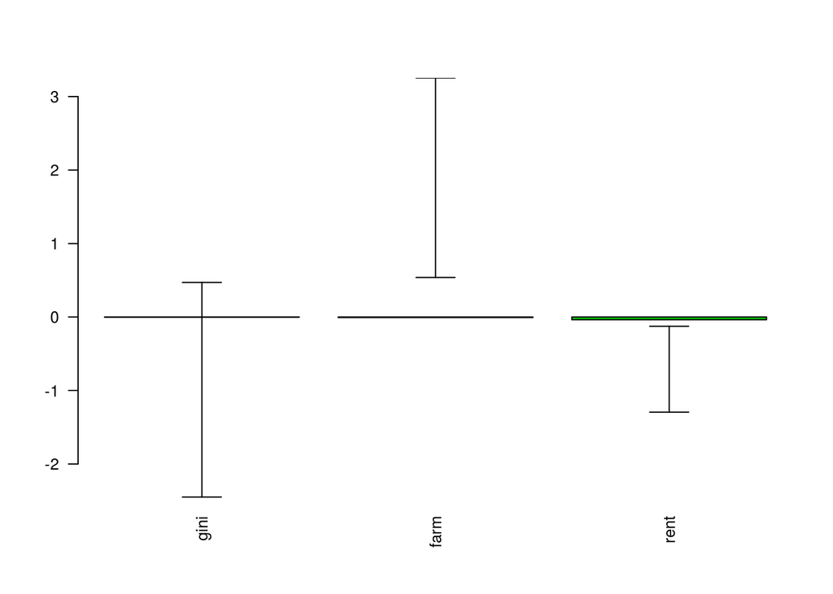

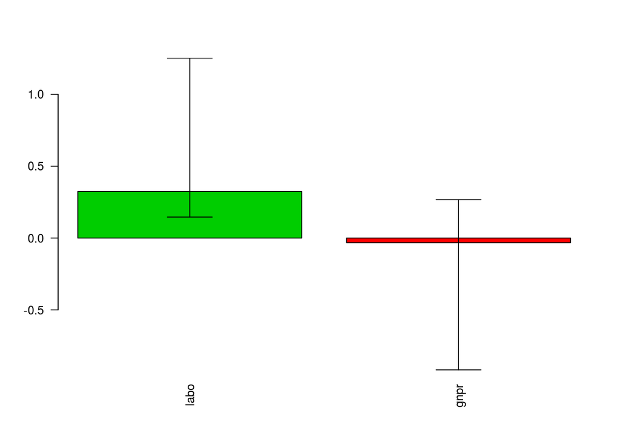

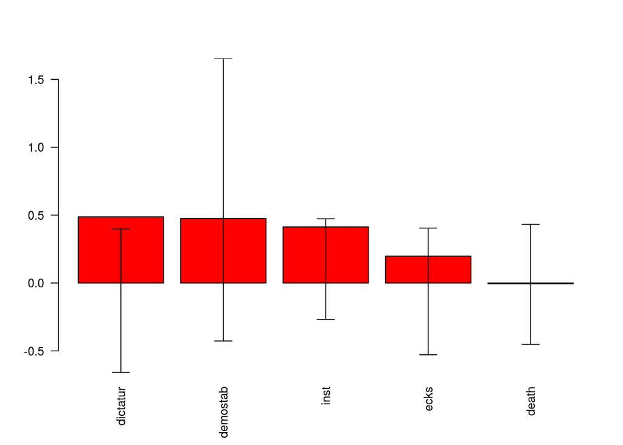

```r
#RGCCA
A               = list(X_agric, X_ind, X_polit)
C               = matrix(c(0, 0, 1, 0, 0, 1, 1, 1, 0), 3, 3)
tau             = c(0, 0, 0)
ncomps          = c(1, 1, 1)
scheme          = "factorial"
scale           = F
init            = "svd"
bias            = F
verbose         = F
scale_size_bloc = F
res_rgcca       = rgcca(A = A, C = C, tau = tau, ncomp = ncomps, scheme = scheme, scale = scale, init = init,
                        bias = bias, verbose = verbose, scale_size_bloc = scale_size_bloc)
#CI with RGCCA
B               = 1000
verbose         = T
plot            = T
ci.res_rgcca    = ci.rgcca(object = res_rgcca, A = A, B = B, verbose = verbose, plot = plot)
```

```r
#Speed
tm = microbenchmark(russet_spls  = ci.spls( f, plot.it = F),
                    russet_rgcca = ci.rgcca(object = res_rgcca, A = A, B = B, verbose = F, plot = F),
                    times = 20)
```

[output not shown]

[output cut: 185 more lines]

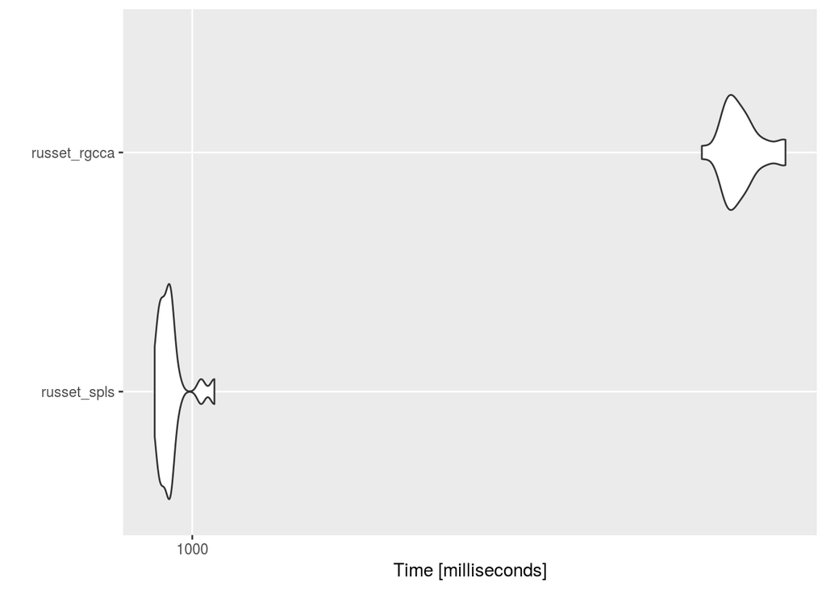

```r
autoplot(tm)
```

```r
#ci.spls is arround 3 times faster than ci.rgcca
TIME = tapply(X = tm$time, INDEX = tm$expr, FUN = mean)
TIME[2]/TIME[1]
```

```
## russet_rgcca
##     3.172973
```

# 3 - Conclusion

Through these differents tests, we could have seen that “ci.spls”/“ci.rgcca” or “spls”/“rgcca” have not the same speed. The advantage is all the time for functions of the package “SPLS”. This lies upon many reasons.  
Some of this raison are linked to stuff that SPLS are not doing:

- PLSR is without no doubt faster than RGCCA. This is the core function call in “ci.spls”. However, no scaling is done with this function, which is not the case with RGCCA. For each bootstrap sample, RGCCA have a step of scaling.
- For each boostrap sample, “ci.rgcca” recalibrate the sign of the loadings thanks to the first loading computed and then compute the correlation between all the components. Those 2 steps are not done in “ci.spls”.
- At the end of dealing with all those boostrap samples, RGCCA has some steps to create a correlation matrix with a CI for each correlation. This part is not present in “ci.spls”

For all those points (except for the scaling part), tests were done in order to see if some strategies could improve the speed of those part (through “microbenchmark” and “profviz”). Tests were done on “mice” data. For this configuration, functions seems to be optimal. Maybe try with other data sets (bigger).

Others are linked to stuff that SPLS is doing:

- SPLS is a sparse method. So in “ci.spls” they are bootstrapping only on the variables selected thanks to SPLS, which is a clear gain in time

One-way of getting closer to SPLS is to improce the speed of RGCCA. An int is to parallelize maybe the computation of the semidefinite matrix M before the while boucle. In any case, here, parallelization thanks to mcapply clearly improve the speed of “ci.rgcca”. We will have to test if this function is working on windows machine because it could not be the case. However, it could be replace by parallel:::parSapply I think. Moreober pbmcapply allows to display time but it clearly takes longer to execute.